# COVID-19 US Vaccination Progress and Distribution Disparities

## Group Members

Gabriel Alwan, Zhengxi Guo, Chenhui Lin, Rossa Sabu

## Introduction:

The COVID-19 pandemic has taken a great toll on the US’s healthcare system and overall economy. In order to return closer to normalcy, a really important strategy is to vaccinate the public as quickly as possible so we as a country can approach heard immunity. Obviously, doing this is easier said than done. Not only are the logistics of vaccine distribution difficult, but convincing people to take the vaccine is also difficult. The United States is a very heterogeneous country, there are many different type of people from different political, economic and demographic backgrounds. This heterogenity leads to a natural and interesting investigation of the explanatory factors of differences in vaccination willingness. While there has definitely been a some level mistrust of the science of COVID-19 from the public, from an anecdotal point of view it seems like many people who affiliate themselves as Republican have been more unwilling to trust the science on the severity of COVID and the efficacy/safety of the vaccines. So, it would seem reasonable to presume that Republican states have been doing “worse” with vaccine acceptance. Upon further investigation we have found articles (listed below) which backed up our point of view. We decided to show whether this hypothesis can be backed up by actual data. In this project, we define vaccine success by state as the proportion of total vaccines a state has actually been used out of the total supply (total vaccines administered / total vaccine supply).

In this project, we don’t exclusively focus on vaccine success between Democratic states (states that voted for Biden) are doing “better” than Republican states (states that voted for Trump). As considered in a Pew Research study (citation given below), there are other factors that might explain for intent to take the vaccine. For example, we consider age as a potential explanatory factor. Other factors that we consider are gender, income levels, and education. Our suspicion is that vaccine success are primarily explained by “politics” but also feel that understanding and appreciation “science” is a factor which is aligned with one’s education level. After investigation, we back up our original presumption Blue States have been doing better than Red States in terms of vaccine roll out (as of April 16th), and we also find that, given the political tendency of a state, the percentage of people without a high school diploma factors in.

Sources that inspired this project:

NBC article on how blue states doing better than red states in terms of vaccine distribution:

https://www.nbcnews.com/politics/politics-news/red-states-u-s-electoral-map-lagging-vaccinations-n1264102

Pew Research article which talks about how red states are lagging behind and various other differences in vaccine usage (income, sex, etc.):

https://www.pewresearch.org/science/2020/12/03/intent-to-get-a-covid-19-vaccine-rises-to-60-as-confidence-in-research-and-development-process-increases/

## Data

**We have a total of 6 data sets that we pulled off the internet. 3 of the data sets are from Kaggle user, the other 3 are from government ACS data. We include the url of the sources and sites that our sources used here and below we include proper citations.**

1. Our first data source is collected from https://www.kaggle.com/paultimothymooney/usa-covid19-vaccinations

Acknowledgments: The uploader from Kaggle originally curated it from https://ourworldindata.org/us-states-vaccinations.

2. Our second data source is collected from

https://www.kaggle.com/unanimad/us-election-2020?select=president_county_candidate.csv

Acknowledgments: The uploader from Kaggle originally curated it from

https://www.bbc.com/news/election-us-2020-53785985

3. Our third data source is collected from (coordinates used for our fun map not for the analysis). The creator of this data set was the original collector of this data.

https://www.kaggle.com/divyeshardeshana/usa-states

4. Our final data sets come from government ACS

Since this is a government agency there are no acknowledgments, this is the primary source.

We retrieve 3 tables from https://data.census.gov/cedsci/

Educational Attainment data:

https://data.census.gov/cedsci/table?q=S1501&g=0100000US.04000.001&tid=ACSST1Y2019.S1501&hidePreview=true

Demographic data:

https://data.census.gov/cedsci/table?q=DP05&g=0100000US.04000.001&tid=ACSDP1Y2019.DP05&hidePreview=true

Income data:

https://data.census.gov/cedsci/table?q=S1901&g=0100000US.04000.001&tid=ACSST1Y2019.S1901&hidePreview=true

**Citation of the websites we obtained the data from:**

1. Mooney, Paul. “USA COVID-19 Vaccinations” Kaggle, 4 May. 2021, https://www.kaggle.com/paultimothymooney/usa-covid19-vaccinations
2. Fontes, Raphael. “US Election 2020” Kaggle, 18 Dec. 2020, https://www.kaggle.com/unanimad/us-election-2020?select=president_county_candidate.csv
3. Ardeshana, Divyesh. “USA States” Kaggle, 2018 https://www.kaggle.com/divyeshardeshana/usa-states/version/1
4. United States Census Bureau, “EDUCATIONAL ATTAINMENT”, Census (ACS), 2019 https://data.census.gov/cedsci/table?q=S1501&g=0100000US.04000.001&tid=ACSST1Y2019.S1501&hidePreview=true
5. United States Census Bureau, “ACS DEMOGRAPHIC AND HOUSING ESTIMATES”, Census (ACS), 2019 https://data.census.gov/cedsci/table?q=DP05&g=0100000US.04000.001&tid=ACSDP1Y2019.DP05&hidePreview=true
6. United States Census Bureau, “AINCOME IN THE PAST 12 MONTHS (IN 2019 INFLATION-ADJUSTED DOLLARS)”, Census (ACS), 2019 https://data.census.gov/cedsci/table?q=S1901&g=0100000US.04000.001&tid=ACSST1Y2019.S1901&hidePreview=true

**Variable Descriptions**

This first data set (“1” in our citation) has 14 variables. However, for the purposes of our analysis we used the following:

•`date:` date of the observation.

•`location:` name of the state or federal entity.

•`total_vaccinations:` total number of doses administered. This is counted as a single dose, and may not equal the total number of people vaccinated, depending on the specific dose regime (e.g. people receive multiple doses). If a person receives one dose of the vaccine, this metric goes up by 1. If they receive a second dose, it goes up by 1 again.

•`total_distributed:` cumulative counts of COVID-19 vaccine doses recorded as shipped in CDC’s Vaccine Tracking System.

•`total_vaccinations_per_hundred:` `total_vaccinations` per 100 people in the total population of the state.

•`share_doses_used:` share of vaccination doses administered among those recorded as shipped in CDC’s Vaccine Tracking System. —> (total_vaccinations / total_distributed)

For more explanation on these variables: https://github.com/owid/covid-19-data/blob/master/public/data/vaccinations/README.md

The second data set (“2” in the citations) has 4 variables (we used all of them in our analysis). The meaning of each variables are:

•`state:` name of the state in United States.

•`candidate:` name of the candidate in each `state`.

•`party:` the abbreviated version of the name of the party, consisting of the first three uppercase letters.

•`total_votes:` number of votes collecting at the location.

The third data set (“3” in the citations) and has the following variable names (used for the interesting map shown later in the report):

•`state:` name of the state in United States.

•`latitude:` Latitude of State.

•`longitude:` Longitude of State.

Our last 3 data sets came from the government ASC data set where we collected the most recent data on education, income and demographic information. All of these data sets included dozens upon dozens of variables. However, for the purposes of our analysis we used the following variables from these data sets

For education data set (“4” in our citation) :

•`state:` name of the state in United States.

•`Estimate Total AGE BY EDUCATIONAL ATTAINMENT Population 25 years and over:`

•`Estimate Total AGE BY EDUCATIONAL ATTAINMENT Population 25 years and over Less than 9th:`

•`Estimate Total AGE BY EDUCATIONAL ATTAINMENT Population 25 years and over 9th to 12th grade, no diploma:`

For demographic data set (“5” in our citation):

•`state:` name of the state in United States.

•`Estimate SEX AND AGE Total population Median age (years):` estimated median age in each state of United States

•`Percent SEX AND AGE Total population Male:` male population in percentage measurement

For income data set (“6” in our citation):

•`state:` name of the state in United States.

•`Estimate Households Median income (dollars):` estimated amount of households median income in dollars in United States

## Data Cleaning

Explanation:

The first part of our data cleaning process revolved around cleaning up our election data set. Our election data set essentially gave us information on the vote counts each candidate received in each county in every state. Because we are only looking at Red states vs Blues states (and obviously because Trump and Biden were the only candidates to win a state in the 2020 presidential election) we filtered out the other candidates receiving votes from our data set. Then, essentially what we did to determine whether a state was “Red” or “Blue” was we added all of each state’s county voting totals together and if Trump had more total votes, the state is Red and if Biden had more votes, the state is Blue.

The next part of our data clean up revolved around cleaning up our vaccine data set. Like explained above, vaccine data set included daily vaccine information on each state/territory. Since we only want to look at the vaccine information on the date April 16th we filter to just include that date. Additionally, the vaccine data set included information on other locations/territories (i.e Guam, American Somoa, etc.) that we did not want to include because we only want to look at the 50 states (and Washington DC) as those are the only states who votes count towards the election results. So we filtered out those other locations. Then we simply merged our vaccine data frame with our election results data frame

Next we read in all the ACS data. What we did was that we obtained a key from the ACS website so we could first have access to ACS data. Then we were able to read in our desired data sets from the ACS website. We found data sets we thought were appropriate on the website, found its “key” and used that “key” to read in the data. The data for all three data sets is 2019 demographic, education and economic data for each US state. We did have to do some String manipulation to remove some unnecessary exclamation points from the column names. We also had to flip the data set so that the states were made rows instead of columns (they were read in as columns).

Then, for our 3 ACS data sets we filtered for only the variables we wanted (described above in the data section) and renamed them to give them reasonable name lengths. We also created a new variable called “propNotHighSchool” which is a variable for each states which is the sum of all 25 year and older people that do not have a high school diploma of that state divided by the total number of 25 year and older people in that state. Additionally, our ACS data included Puerto Rico data, however we do not need that information so we filtered it out.

Lastly, we simply combined five of our data sets together which includes the ASC, presidential and vaccine information all together. So our grand data set should have states as the rows, and vaccine, political, education, income and demographic information as columns. For more information see the provided rmd file which includes all of the code

FinalProjectReport

## Methods

One of the most important steps in allowing the data to speak is to visualize the data. We begin our data storytelling with a map of the US labeling states as Blue vs. Red. On this map, we superimpose symbols that are proportional to the variable of interest, shared dosed used. We then follow-up this visualization with distribution plots, namely, histograms and a box plot.

Our visualization is then followed with a formal two-sample mean test. The two-sample mean test only considers one factor. Since we are interested in seeing if there are explanatory effects, we then turn regression analysis. Our regression modeling considers five potential explanatory variables: whether a state is “blue”, the median income of a state, the median age of a state, the proportion of males in a state, and the proportion of people 25 and older who do not have a high school degree in a state. To narrow down the variables to keep in the model, we explore the use of model selection. One common regression model searching technique is step wise selection (forward or backward). We took it upon us to find out about different methods for model selection. We found that a method called step wise selection is particularly useful for large data sets because it is computationally fast. However, step wise selection doesn’t consider all possible combinations of explanatory variables. Since we have a small data set and not many explanatory variables, we implement an exhaustive search known as “all possible subsets” guided by a commonly-used criterion BIC using the leaps package. Once we identify the variables to use, we fit the model and perform standard regression diagnostics. We conclude with an interpretation of the identified model.

## Initial Figures

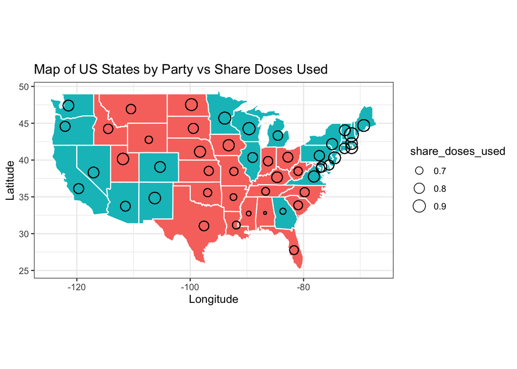

```r
## make sure to install this install.packages(c("maps", "mapdata"))
library(ggplot2)
library(maps)
library(mapdata)
library(tidyverse)

states = map_data("state")%>%
rename(State = region)%>%
mutate(State = str_to_title(State))%>%
select(-subregion)
states$State[states$State == "District Of Columbia"] = "District of Columbia"


states = merge(state_df, states, by = "State")%>%
  group_by(State)%>%
  mutate(order = sort(order))


state.coords = read.csv("USA_States.csv")%>%
rename(point.y  = Latitude, point.x = Longitude)%>%
  filter(State!="Alaska" & State != "Hawii")

states = merge(state.coords, states, by = "State")%>%
  group_by(State)%>%
  mutate(order = sort(order))

ggplot(data = states) +
  geom_polygon(aes(x = long, y = lat, fill = Blue, group = group), color = "white") +
  coord_fixed(1.3) +
  guides(fill=FALSE)+
  geom_point(data = states, aes(x = point.x, y = point.y, size = share_doses_used), shape = 1)+
  theme_bw()+ ggtitle("Map of US States by Party vs Share Doses Used") + xlab("Longitude")+ ylab("Latitude")
```

Figure 1 - Share doses used on US 2020 presidential election map (Blue vs. Red States)

From Figure 1, it appears from the map that the larger circles tend to be larger on Blue (Democratic-leaning) states than Red (Republican-leaning). This particularly evident with northeastern states and with upper midwest states including Wisconsin. To get a clearer sense of the distribution of the data values, we now turn to a histogram of the data.

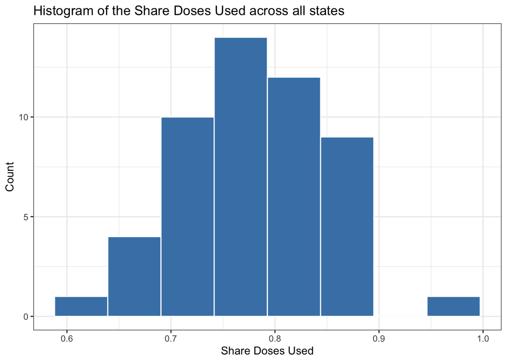

```r
ggplot(state_df, aes(x = share_doses_used))+
  geom_histogram(color = "white", fill = "steelblue", bins = 8)+
  ylab("Count")+xlab("Share Doses Used")+
  ggtitle("Histogram of the Share Doses Used across all states")+
  theme_bw()
```

Figure 2 - Histogram of share doses used across all states

The overall histogram (Figure 2) shows that the values range from around 0.6 to near 1.0 with a distribution that appears normally distributed. What we don’t see from this histogram are the Blue vs. Read states. So, we now separate the overall histogram into two histograms by political leaning factor.

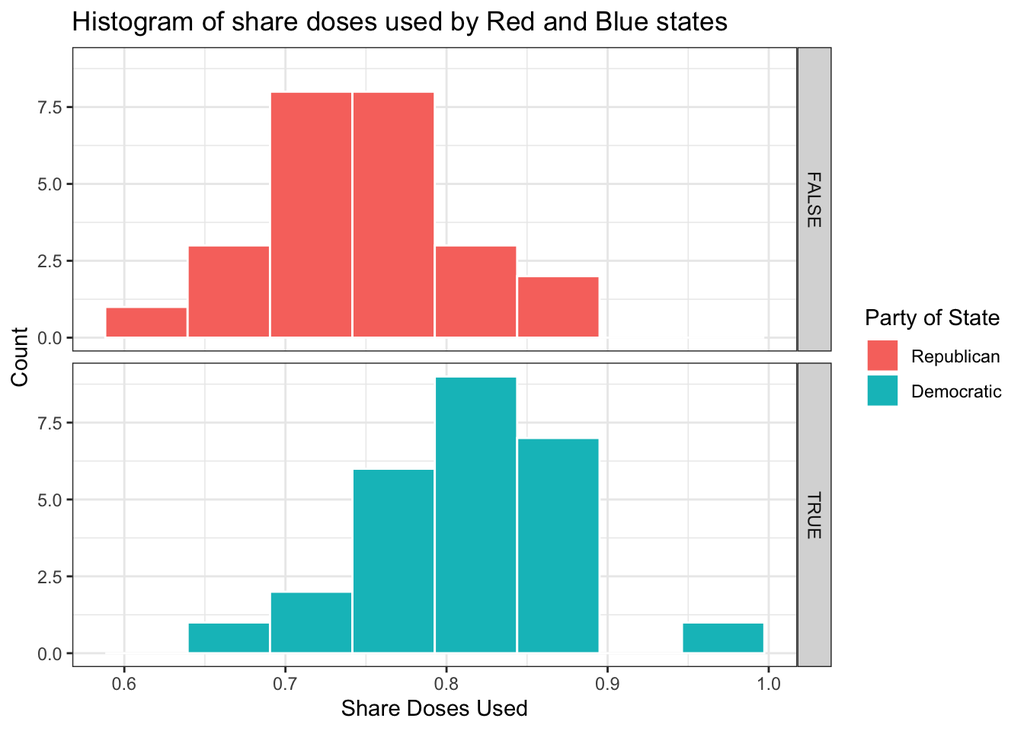

```r
ggplot(state_df, aes(x = share_doses_used))+
  geom_histogram(aes(fill = Blue), color = "white",  bins = 8)+
  facet_grid(Blue ~ .)+
  theme_bw()+
  ggtitle("Histogram of share doses used by Red and Blue states")+
  ylab("Count")+xlab("Share Doses Used")+ scale_fill_discrete(name = "Party of State", labels = c("Republican", "Democratic"))
```

Figure 3 - Histograms of share doses used for Red states (top) and for Blue states (bottom)

From Figure 3, we clearly see that the Blue state histogram is shifted to the right of the Red state histogram suggesting that there tends to be higher share doses in Blue states as we suspected from the US map. Interestingly, the each of the histograms seem compatible with the normal distribution. Another excellent visualization tool for comparison is side-by-side boxplots.

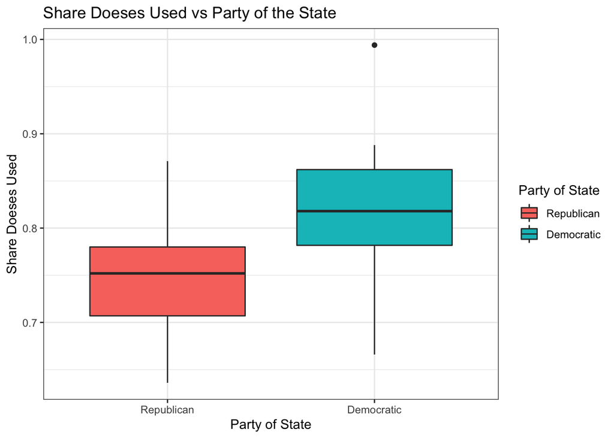

```r
state_df$Blue = factor(state_df$Blue)
ggplot(data=state_df, aes(y= share_doses_used, x=Blue, fill=Blue ) ) + geom_boxplot() + ggtitle("Share Doeses Used vs Party of the State")+  ylab("Share Doeses Used") + xlab("Party of State") + theme_bw()+ scale_fill_discrete(name = "Party of State", labels = c("Republican", "Democratic"))+
  scale_x_discrete(labels = c("Republican","Democratic"))
```

Figure 4 - Side-by-side boxplots of share doses used for Red states (left) vs Blue states (right)

From Figure 4, we clearly see the Blue states generally have higher share doses than Red states. We can see that the lower 25th percentile of the Blue states is about equal to the upper 75th percentile of the Red states. We also see that the levels of variability, as visuallized by the width of the boxes, are nearly equal for Blue and Red states. Let’s know turn to formal statistical analysis of the data.

```r
blue = state_df$share_doses_used[state_df$Blue == TRUE]
red = state_df$share_doses_used[state_df$Blue == FALSE]

t.test(red, blue)
```

```
##
##  Welch Two Sample t-test
##
## data:  red and blue
## t = -3.8697, df = 49, p-value = 0.0003222
## alternative hypothesis: true difference in means is not equal to 0
## 95 percent confidence interval:
##  -0.10250688 -0.03243158
## sample estimates:
## mean of x mean of y
## 0.7498000 0.8172692
```

We find the p-value to be 0.0003222 for the two sample t-test. The null hypothesis is that there is no difference in the underlying means for Blue and Red states. Given that the p-value is so small, we have strong statistical evidence to reject the null hypothesis in favor of the conclusion that the mean difference is not 0. The 95% confidence interval for the mean of Red states minus the mean of Blue states does not include 0 which is consistent with rejection of the null hypothesis. The interval ranges over negative numbers implying we would could that the mean of Red states is less than the mean of Blue states. We know consider other factors in our analysis.

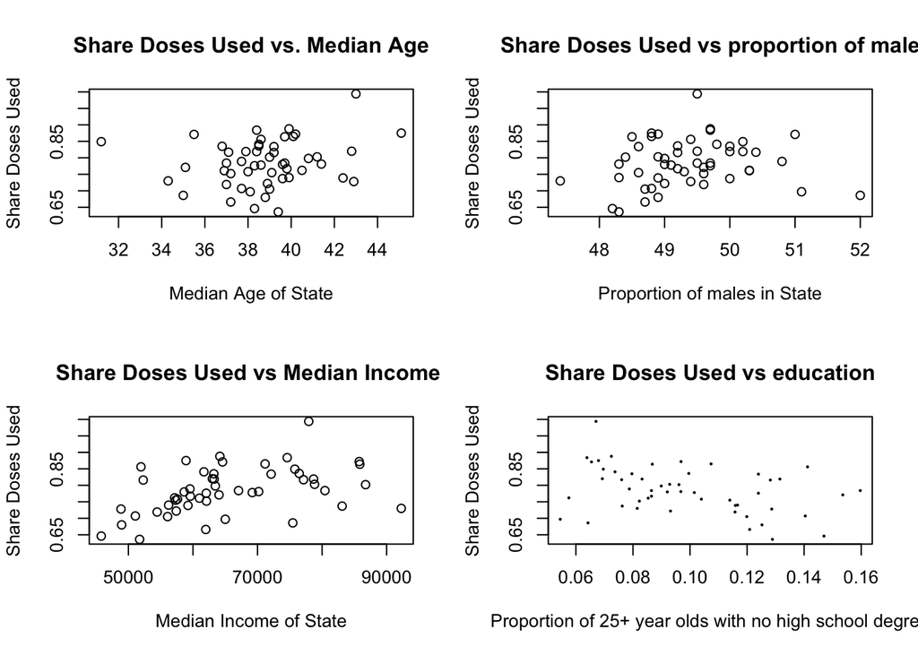

```r
matrix = matrix(data = c(1,2,3, 4), nrow = 2, ncol = 2)
layout(matrix)

plot(x = state_df$medianAge, y = state_df$share_doses_used, xlab = "Median Age of State", ylab = "Share Doses Used", main = "Share Doses Used vs. Median Age")

plot(x = state_df$median_income, y = state_df$share_doses_used, xlab = "Median Income of State", ylab = "Share Doses Used", main = "Share Doses Used vs Median Income ")

plot(x = state_df$percentMale, y = state_df$share_doses_used, xlab = "Proportion of males in State", ylab = "Share Doses Used", main = "Share Doses Used vs proportion of male")

plot(x = state_df$propNotHighSchool, y = state_df$share_doses_used, xlab = "Proportion of 25+ year olds with no high school degree", ylab = "Share Doses Used", main = "Share Doses Used vs education" , cex = 0.2)
```

Figure 5 - Four scatter plots of share doses used against median age, percent male, median income and the proportion of people 25 and older who did not finish high school.

To get a feel the relationships between the Y variable and the numeric variables, we show in Figure 5 the scatter plots against median age, percent male, median income, and percent of 25+ who didn’t finish high school. There doesn’t appear to be obvious relationships between our Y variable and the age and gender variables. There is possibly a positive relationship with the income variable. The clearest relationship appears to be with the education variable; in particular, the relationship appears negative implying states with higher proportion of adults not having a high school education tend to have lower levels of share doses used. We now will run a regression on these four X variables along with 1/0 (yes/no) variable for being a Blue state or not.

```r
m <- lm(state_df$share_doses_used ~ (state_df$BlueState +  state_df$medianAge +
state_df$median_income + state_df$percentMale + state_df$propNotHighSchool))

summary(m)
```

```
##
## Call:
## lm(formula = state_df$share_doses_used ~ (state_df$BlueState +
##     state_df$medianAge + state_df$median_income + state_df$percentMale +
##     state_df$propNotHighSchool))
##
## Residuals:
##      Min       1Q   Median       3Q      Max
## -0.12272 -0.02801 -0.00816  0.03734  0.13013
##
## Coefficients:
##                              Estimate Std. Error t value Pr(>|t|)
## (Intercept)                -3.233e-01  7.446e-01  -0.434   0.6662
## state_df$BlueState          4.643e-02  2.516e-02   1.846   0.0715 .
## state_df$medianAge          6.029e-03  4.620e-03   1.305   0.1985
## state_df$median_income      1.219e-06  1.220e-06   0.999   0.3233
## state_df$percentMale        1.650e-02  1.230e-02   1.342   0.1864
## state_df$propNotHighSchool -4.521e-01  4.091e-01  -1.105   0.2750
## ---
## Signif. codes:  0 '***' 0.001 '**' 0.01 '*' 0.05 '.' 0.1 ' ' 1
##
## Residual standard error: 0.05858 on 45 degrees of freedom
## Multiple R-squared:  0.3776, Adjusted R-squared:  0.3085
## F-statistic:  5.46 on 5 and 45 DF,  p-value: 0.0005206
```

From the regression output, the t-tests don’t seem to indicate any significant effect. But, the F-statistic which looks at all the variables collectively is associated with a very small p-value (0.0005206). This implies that we want to hold on to at least one variable. The question now is which variables to keep versus not. We found that there is a procedure in the R-package called “leaps” that will look at all combinations of X variables and look at a metric called BIC. From what we understand, BIC is a measure that balances between explaining (fitting) the data well and keeping the model simpler (i.e., not having unnecessary extra variables). Below we put the leaps package in our session and show a plot of BIC against the best 1-variable, 2-variable, 3-variable, 4-variable, and 5-variable models.

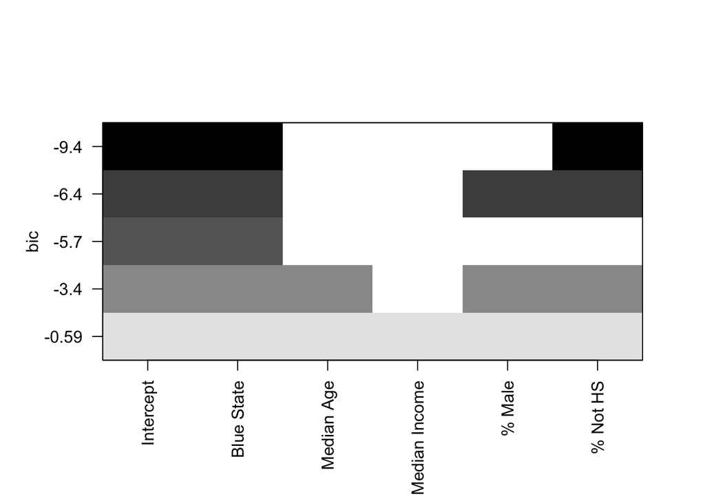

```r
library(leaps)

full = lm(share_doses_used ~BlueState +  medianAge +
median_income + percentMale + propNotHighSchool, data = state_df)

subout = regsubsets(formula(full), data = state_df)
regsum = summary(subout)

plot(subout, scale = "bic", labels = c("Intercept", "Blue State", "Median Age", "Median Income",
                                       "% Male", "% Not HS"))
```

As noted, the leaps package will look at all 1-variable models, all 2-variable models, etc. So, all possible combinations are considered. The plot above shows the best 1-variable model, the best 2-variable model, the best 3-variable model, the best 4-variable model, and the best 5-variable model. Now we are left to determine the best among the best. As it turns out, smaller BIC is desirable. From the plot, we see that the smallest BIC (around -9.4) is associated with a model based on an intercept, the Blue state variable, and the education variable. We use this information to now fit a regression these two selected variables.

```r
m = lm(formula = share_doses_used ~ BlueState + propNotHighSchool,
    data = state_df)

summary(m)
```

```
##
## Call:
## lm(formula = share_doses_used ~ BlueState + propNotHighSchool,
##     data = state_df)
##
## Residuals:
##       Min        1Q    Median        3Q       Max
## -0.129940 -0.031736 -0.002616  0.038814  0.151674
##
## Coefficients:
##                   Estimate Std. Error t value Pr(>|t|)
## (Intercept)        0.83707    0.03342  25.044  < 2e-16 ***
## BlueState          0.06296    0.01644   3.831  0.00037 ***
## propNotHighSchool -0.86101    0.30896  -2.787  0.00760 **
## ---
## Signif. codes:  0 '***' 0.001 '**' 0.01 '*' 0.05 '.' 0.1 ' ' 1
##
## Residual standard error: 0.05839 on 48 degrees of freedom
## Multiple R-squared:  0.3405, Adjusted R-squared:  0.313
## F-statistic: 12.39 on 2 and 48 DF,  p-value: 4.584e-05
```

We find above the regression on the two selected variables. Even though we used BIC to guide our variable selection, it is worth noting that the p-values for both the variables are extremely small (0.00037 and 0.0076). The positive coefficient on the Blue state variable is consistent with our earlier conclusions that Blue states tend to have higher share doses used. The negative coefficient on the education variable indicates that holding political factor constant, states with higher proportion not non-HS educated students tend to have lower share doses used. This result is consistent with our initial hypothesis that having less education is associated with individuals who are not understanding or embracing science. We should note that the model has a R-sq value of 34.05%. Even though we seem to be explaining certain significant effects, this R-sq value suggests that there is a lot of variation still unexplained. With algebra, we can break down the regression as follows:

Blue States:

Fitted Y = 0.90003 - 0.86101*propNotHighSchool

Red States:

Fitted Y = 0.83707 - 0.86101*propNotHighSchool

To check how well the regression model fits the data and meets standard assumptions, we produce a couple of residual plots.

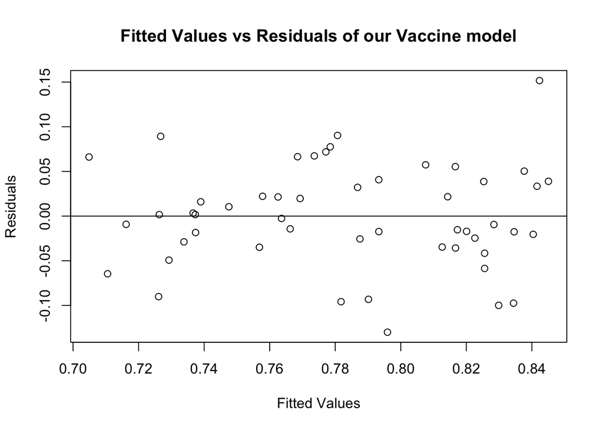

```r
plot(x = m$fitted.values, y = m$residuals, ylab = "Residuals", xlab = "Fitted Values", main = "Fitted Values vs Residuals of our Vaccine model")
abline(0,0)
```

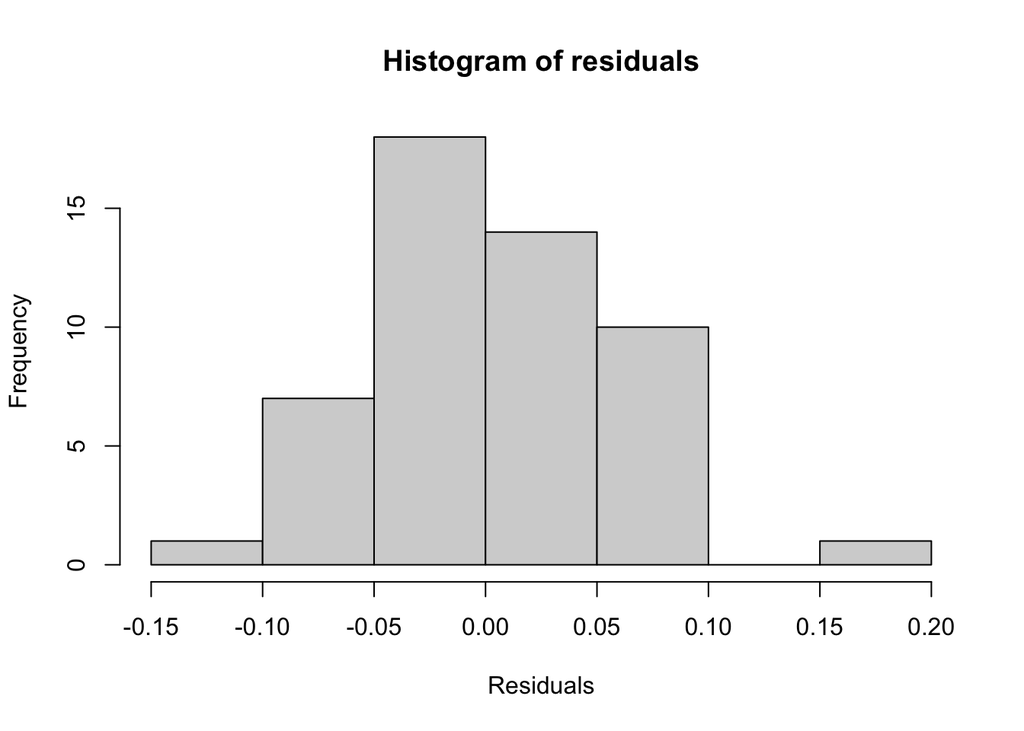

```r
hist(m$residuals, main = "Histogram of residuals", ylab = "Frequency", xlab = "Residuals")
```

The residuals vs. fitted values plot shows no pattern which indicates that we did a good job explaining the Y variable with the variables in the regression. The histogram shows the residuals to be normally distributed which is also good in terms of standard regression assumptions. All in all, the regression based on the two chosen explanatory variables seems to be appropriate.

## Conclusion:

In our analysis, we find that Blue states have been doing better than Red states in terms of the proportion of available vaccines administered (as of April 16th). We saw this conclusion initially with visualizations (US map, separated histograms, and side-by-side boxplots). Since we have read in popular press that there factors may explain vaccine intent, we then did a more complete analysis of various potential explanatory variables (Blue state variable, gender proportion, median age, median income, and an education variable). We explored these several variables in a regression framework and used a common model selection method based on a criterion known as BIC. In the end, we found that in addition to the poltical variable, the education variable had a significant explanatory effect. In particular, we found that states with higher proportion of non-HS educated adults are associated with lower proportion of vaccines being administered. It is interesting and a bit suprising that there was no strong evidence with the age, gender, and income variables.

We believe that our analysis provides some initial insights on what demographics tend to be willing to take the COVID vaccine. With this said, our model only explains around 35% of the variation in the data. This implies a shortcoming to our analysis in that there is a considerable amount of the COVID vaccine usage data that we were not able to explain. For example, we did not consider racial or religious variables which may have an effect. There may be also distribution/logistic variables that need to be consider; for example, number of COVID adminstering sites per capita. There are many more other variables that need to be pondered. By considering more variables we might reveal alternative explanations for why Blue and Red states differ more than simply saying a state is Blue versus Red. Even though we are not running an experiment to get true causual explanations, by exploring more variables we can make more adjustments on variables and get closer to possible causal effects.

Putting aside the question of casual effects, there is no denying that individuals in Blue states tend to have a greater willingness to take the vaccine than individuals in Red states. This fact alone is a valuable takeaway from the data analysis. The date justify for resources (advertising, PSA’s, etc.) to be directed to Red states to help convince the populace to take the vaccine. The information on lower education being associated with lower acceptance of the vaccine can direct public health advocates to reach out to the lower education demographics (e.g., those with limited skill jobs) to learn how to vaccine acceptance can be increased.